# Homework 2

Jesus Tuesta

2023-05-22

# 1 Mass shootings in the US

```
## Rows: 125
## Columns: 14
## $ case                 <chr> "Oxford High School shooting", "San Jose VTA shoo…
## $ year                 <dbl> 2021, 2021, 2021, 2021, 2021, 2021, 2020, 2020, 2…
## $ month                <chr> "Nov", "May", "Apr", "Mar", "Mar", "Mar", "Mar", …
## $ day                  <dbl> 30, 26, 15, 31, 22, 16, 16, 26, 10, 6, 31, 4, 3, …
## $ location             <chr> "Oxford, Michigan", "San Jose, California", "Indi…
## $ summary              <chr> "Ethan Crumbley, a 15-year-old student at Oxford …
## $ fatalities           <dbl> 4, 9, 8, 4, 10, 8, 4, 5, 4, 3, 7, 9, 22, 3, 12, 5…
## $ injured              <dbl> 7, 0, 7, 1, 0, 1, 0, 0, 3, 8, 25, 27, 26, 12, 4, …
## $ total_victims        <dbl> 11, 9, 15, 5, 10, 9, 4, 5, 7, 11, 32, 36, 48, 15,…
## $ location_type        <chr> "School", "Workplace", "Workplace", "Workplace", …
## $ male                 <lgl> TRUE, TRUE, TRUE, TRUE, TRUE, TRUE, TRUE, TRUE, T…
## $ age_of_shooter       <dbl> 15, 57, 19, NA, 21, 21, 31, 51, NA, NA, 36, 24, 2…
## $ race                 <chr> NA, NA, "White", NA, NA, "White", NA, "Black", "B…
## $ prior_mental_illness <chr> NA, "Yes", "Yes", NA, "Yes", NA, NA, NA, NA, NA, …
```

## 1.1 Explore the data

### 1.1.1 Specific questions

- Generate a data frame that summarizes the number of mass shootings per year.

```r
#Summarize number of mass shooting per year
mass_shootings %>%
  #Group by year
  group_by(year) %>%
  #Count mass shootings by year
  summarise(count=n())
```

```
## # A tibble: 37 × 2
##     year count
##    <dbl> <int>
##  1  1982     1
##  2  1984     2
##  3  1986     1
##  4  1987     1
##  5  1988     1
##  6  1989     2
##  7  1990     1
##  8  1991     3
##  9  1992     2
## 10  1993     4
## # ℹ 27 more rows
```

- Generate a bar chart that identifies the number of mass shooters associated with each race category. The bars should be sorted from highest to lowest and each bar should show its number.

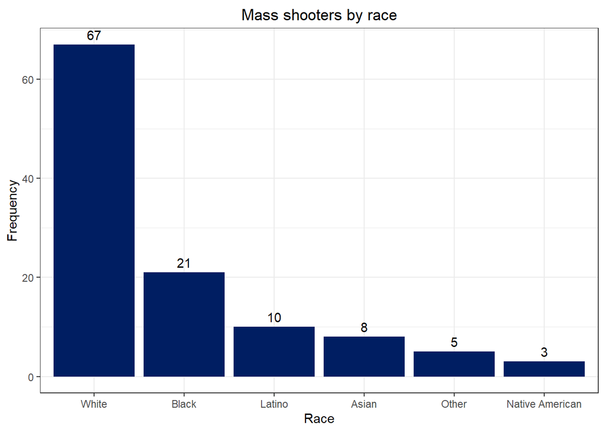

```r
#Mass shootings by race
mass_shootings %>%
  #Take only observations where race is not NA
  filter(complete.cases(race)) %>%
  #Group it by race
  group_by(race) %>%
  #Count the mass shooting by race
  summarise(count=n()) %>%
  #Sort it descendingly
  arrange(desc(count)) %>%
  #Set the aesthetic
  ggplot(aes(x=fct_reorder(race,count, .desc=TRUE), y=count)) +
  #Make a column graph filled by LBS colour
  geom_col(fill='#001e62') +
  #Add a text with the value of each bar
  geom_text(aes(label = count), vjust = -0.5, color = "black") +
  #Black and white theme
  theme_bw() +
  #Add labels to axis and title
  labs(x='Race', title='Mass shooters by race', y='Frequency') +
  #Put the title at the middle
   theme(plot.title = element_text(hjust=0.5, vjust=0.5) )
```

- Generate a boxplot visualizing the number of total victims, by type of location.

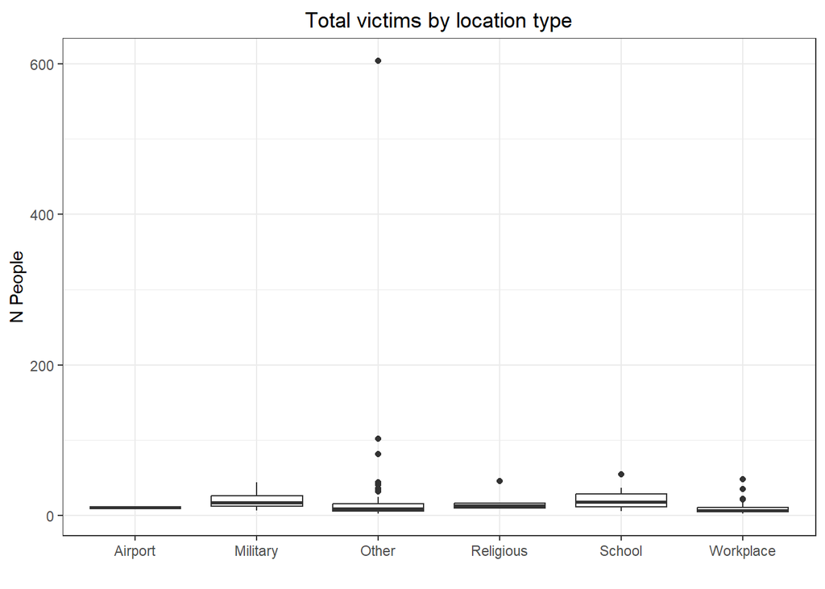

```r
#Boxplot of total victims by location type
mass_shootings  %>%
  #Set the aesthetic
  ggplot(aes(x=location_type, y=total_victims)) +
  #Make a boxplot graph with a black and white theme
  geom_boxplot() + theme_bw() +
  #Add labels and title
  labs(y='N People', title='Total victims by location type', x='') +
   theme(plot.title = element_text(hjust=0.5, vjust=0.5) )
```

- Redraw the same plot, but remove the Las Vegas Strip massacre from the dataset.

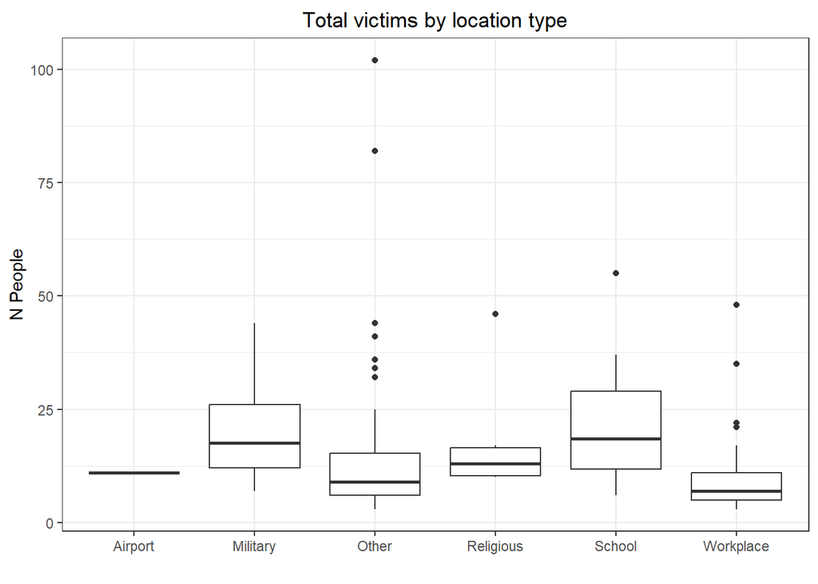

```r
#Same as before but removing the Las Vegas Strip massacre
mass_shootings  %>%
  #Filter and take out the Las vegas massacre
  filter(case!='Las Vegas Strip massacre') %>%
  #All else stay the same
  ggplot(aes(x=location_type, y=total_victims)) +
  geom_boxplot() + theme_bw() +
  labs(y='N People', title='Total victims by location type', x='') +
   theme(plot.title = element_text(hjust=0.5, vjust=0.5) )
```

### 1.1.2 More open-ended questions

Address the following questions. Generate appropriate figures/tables to support your conclusions.

- How many white males with prior signs of mental illness initiated a mass shooting after 2000?

```r
#Males shooters with prior mental illness
mass_shootings %>%
  #Filter it for males shooter, happening after 2000 with previous mental illness and white race
  filter(male==TRUE & year>2000 & prior_mental_illness=='Yes' & race=='White') %>%
  #Count total cases
  summarise(total=n())
```

```
## # A tibble: 1 × 1
##   total
##   <int>
## 1    22
```

- Which month of the year has the most mass shootings? Generate a bar chart sorted in chronological (natural) order (Jan-Feb-Mar- etc) to provide evidence of your answer.

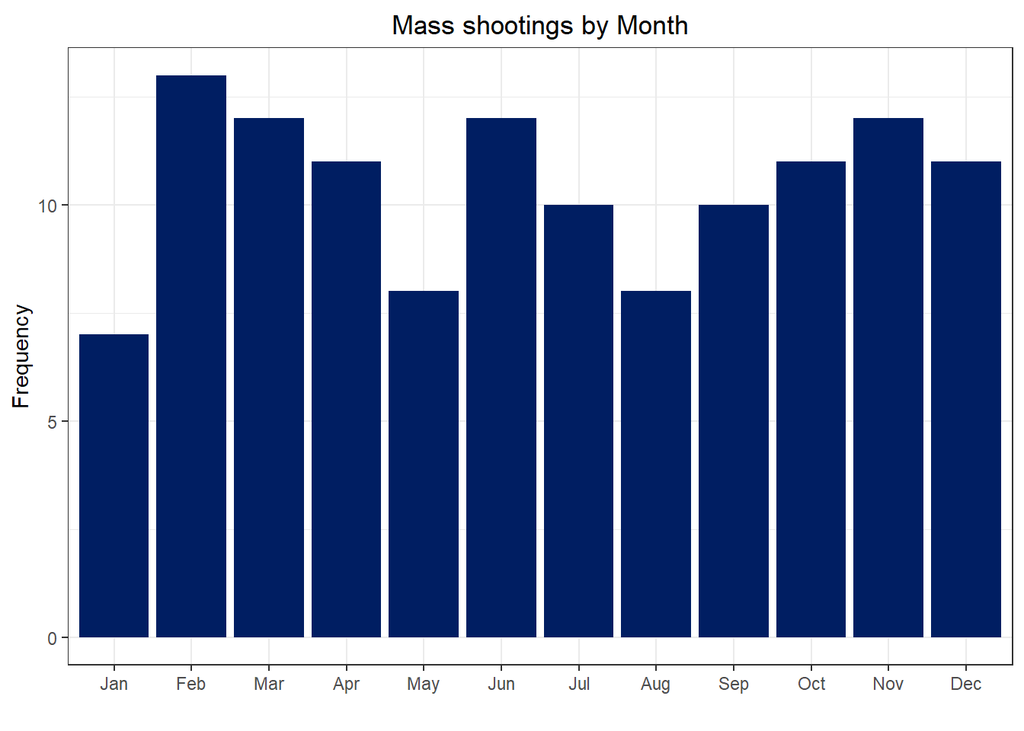

```r
#Set a vector with the appropiater order
months_order <- c("Jan", "Feb", "Mar", "Apr", "May", "Jun", "Jul", "Aug", "Sep", "Oct", "Nov", "Dec")

#Add the factor to the months date in the data set
mass_shootings$month<- factor(mass_shootings$month, levels = months_order)

#Make the graph
mass_shootings %>%
  #Calculate the total shooting by month
  group_by(month) %>%
  summarise(count=n()) %>%
  #Make a column graph
  ggplot(aes(x=month, y=count)) +
  geom_col(fill='#001e62') +
  #Set the appearance parameters
  theme_bw() +
  labs(x='', title='Mass shootings by Month', y='Frequency') +
   theme(plot.title = element_text(hjust=0.5, vjust=0.5) )
```

- How does the distribution of mass shooting fatalities differ between White and Black shooters? What about White and Latino shooters?

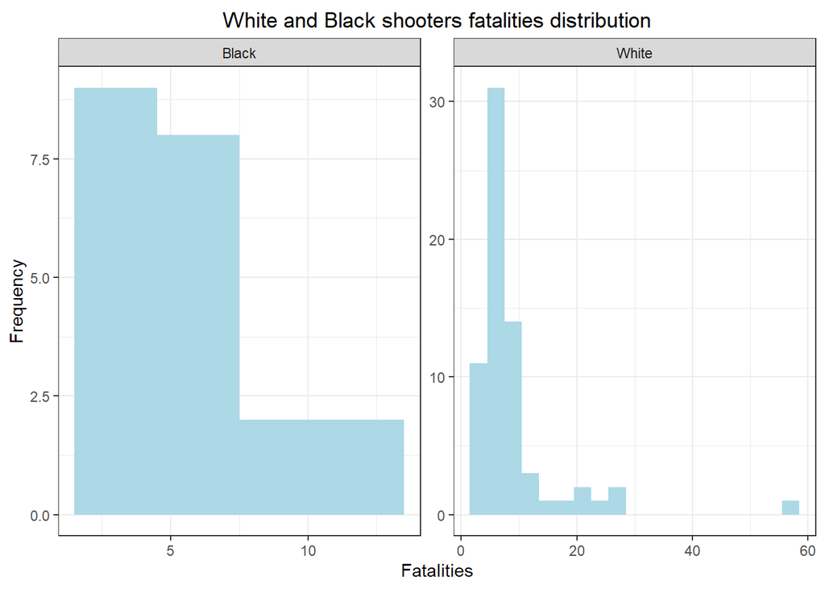

```r
#Mass shooting by race
mass_shootings %>%
  #Only takes the shootings done by white and black shooters
  filter(race=='White' | race=='Black') %>%
  #Make a fatality histogram by race
  ggplot(aes(x=fatalities)) +
  geom_histogram(binwidth = 3, fill = "#ADD8E6")  + #Make a histogram
  facet_wrap(~race, scales='free') +
  #Set the appearance parameters
  labs(x = "Fatalities", y = "Frequency", title = "White and Black shooters fatalities distribution") +
  theme_bw() + #Add the labels
   theme(plot.title = element_text(hjust=0.5, vjust=0.5) ) #Put the title in the middle
```

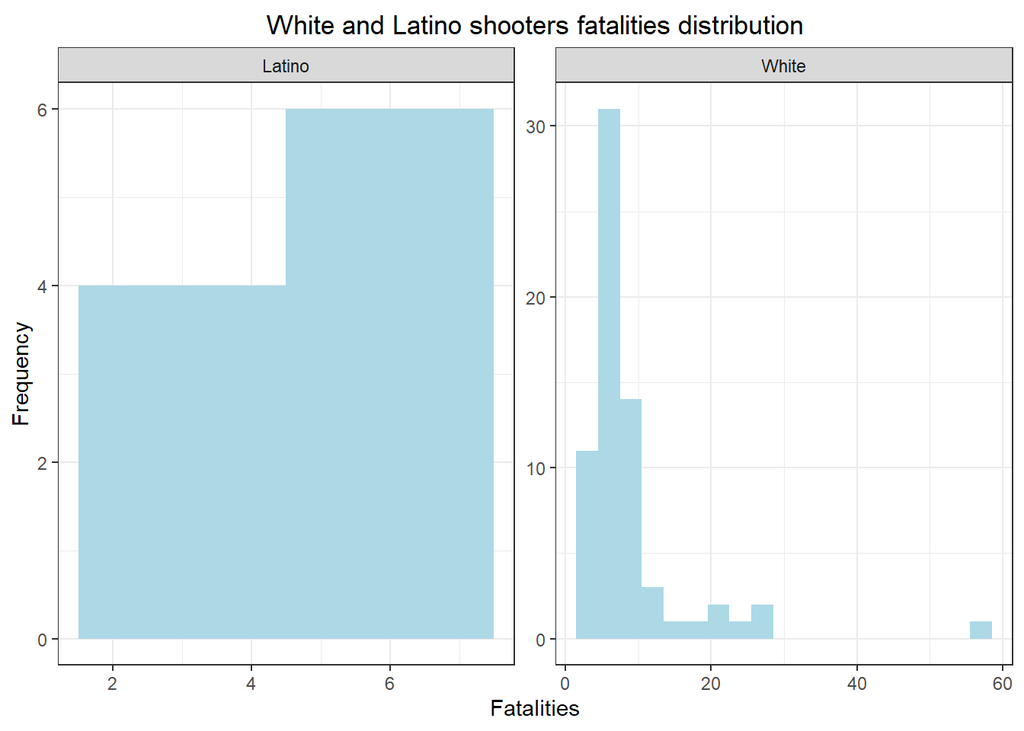

```r
#Mass shooting by race
mass_shootings %>%
  #Filter by race white and latino
  filter(race=='White' | race=='Latino') %>%
  #Make the graph
  ggplot(aes(x=fatalities)) +
  geom_histogram(binwidth = 3, fill = "#ADD8E6")  + #Make a histogram
  facet_wrap(~race, scales='free') +
  #Add labes
  labs(x = "Fatalities", y = "Frequency", title = "White and Latino shooters fatalities distribution") +
  #Add aesthetics
  theme_bw() +
   theme(plot.title = element_text(hjust=0.5, vjust=0.5) ) #Put the title in the middle
```

### 1.1.3 Very open-ended

- Are mass shootings with shooters suffering from mental illness different from mass shootings with no signs of mental illness in the shooter?

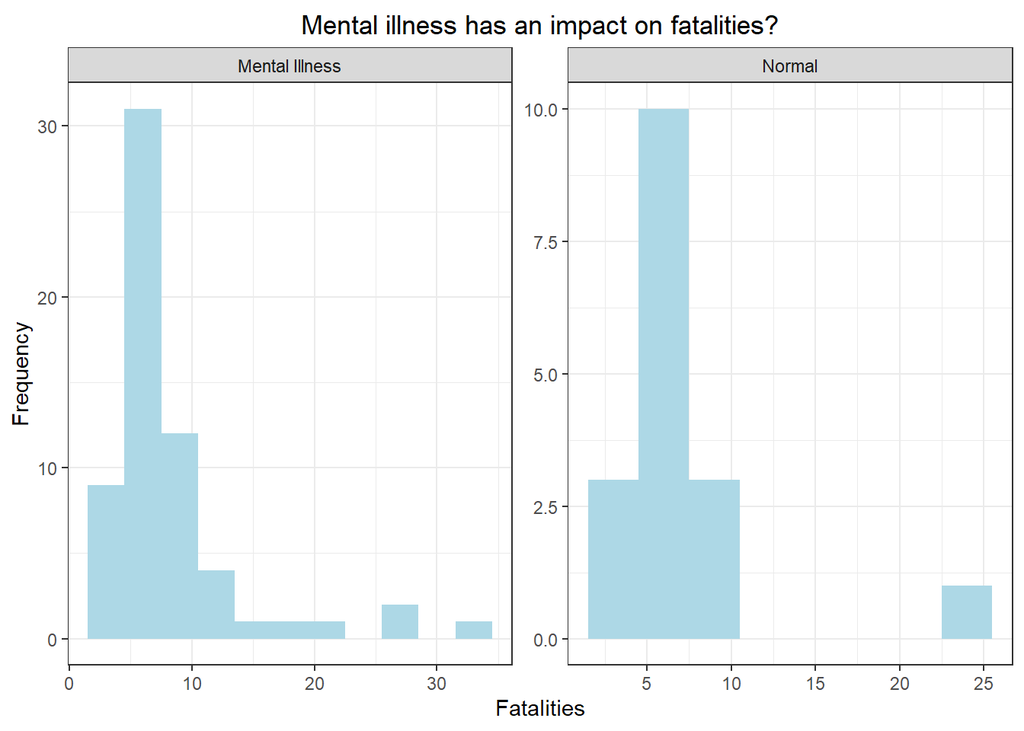

```r
#Graph of fatalities by mental illness
mass_shootings %>%
  #Only take the cases where the variable mental illness is complete
  filter(complete.cases(prior_mental_illness)) %>%
  mutate(prior_mental_illness=ifelse(prior_mental_illness=='No','Normal','Mental Illness')) %>%
  #Make a histogram
  ggplot(aes(x=fatalities)) +
  geom_histogram(binwidth = 3, fill = "#ADD8E6")  + #Make a histogram
  #Repeat it by mental illness
  facet_wrap(~prior_mental_illness, scales='free') +
  #Add a text for the median value
  labs(x = "Fatalities", y = "Frequency", title = "Mental illness has an impact on fatalities?") +
  theme_bw() + #Add the labels
   theme(plot.title = element_text(hjust=0.5, vjust=0.5) ) #Put the title in the middle
```

The graph don’t show a clear significant difference in fatalities with both distribution having its mode around 8.

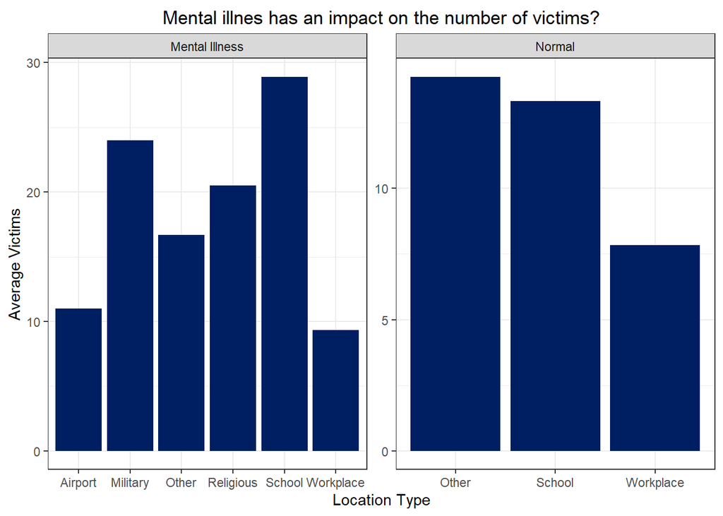

```r
#Graph of victims by mental illness
mass_shootings %>%
  #Transform the dataset
  filter(complete.cases(prior_mental_illness)) %>%
  mutate(prior_mental_illness=ifelse(prior_mental_illness=='No','Normal','Mental Illness')) %>%
  #Estimate the average total victims per class
  group_by(prior_mental_illness,location_type ) %>%
  summarise(count=mean(total_victims)) %>%
  #Make the column graph
  ggplot(aes(x=location_type, y=count)) +
    geom_col(fill='#001e62') +
  #Repeat it by mental illness
  facet_wrap(~prior_mental_illness, scales='free') +
  #Add labels and aesthetics
  labs(x = "Location Type", y = "Average Victims", title = "Mental illnes has an impact on the number of victims?") +
  theme_bw() +
   theme(plot.title = element_text(hjust=0.5, vjust=0.5) ) #Put the title in the middle
```

- Assess the relationship between mental illness and total victims, mental illness and location type, and the intersection of all three variables.

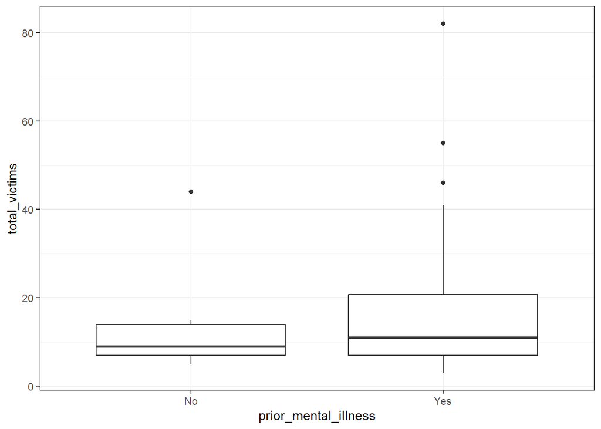

```r
#Graph of total victims by mental illness
mass_shootings %>%
  filter(complete.cases(prior_mental_illness)) %>%
  ggplot(aes(x=prior_mental_illness, y=total_victims)) +
  geom_boxplot() + theme_bw()
```

Shooters with prior mental illness seems to have higher victims than those without them.

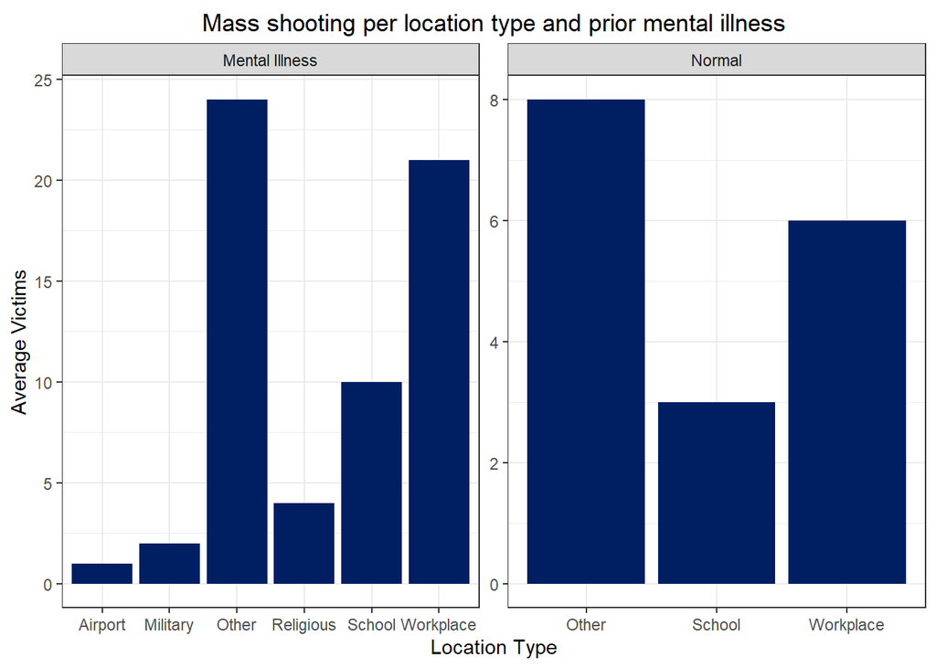

```r
#Mass shooting by location and mental illness
mass_shootings %>%
  #Manage the data set
  filter(complete.cases(prior_mental_illness)) %>%
  mutate(prior_mental_illness=ifelse(prior_mental_illness=='No','Normal','Mental Illness')) %>%
  group_by(prior_mental_illness,location_type ) %>%
  summarise(count=n()) %>%
  #Make the column graph of mass shootings by location type
  ggplot(aes(x=location_type, y=count)) +
    geom_col(fill='#001e62') +
  #Repeat it by mental illness
  facet_wrap(~prior_mental_illness, scales='free') +
  #Add labels
  labs(x = "Location Type", y = "Average Victims", title = "Mass shooting per location type and prior mental illness") +
  theme_bw() +
  #Put the title in the middle
   theme(plot.title = element_text(hjust=0.5, vjust=0.5) )
```

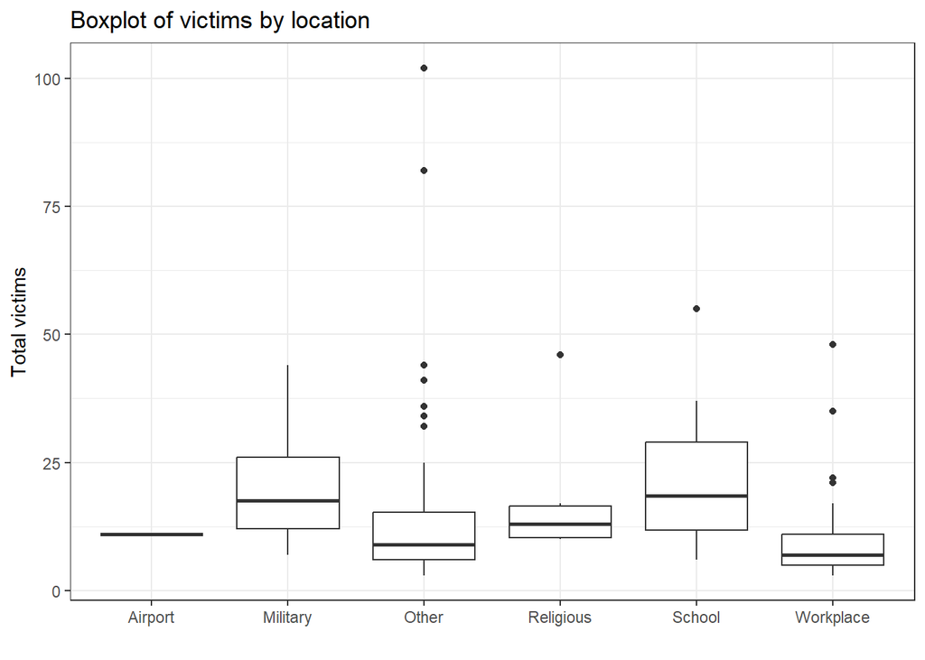

```r
#Total victims by location type if we filter the outliers
mass_shootings %>%
  filter(case!='Las Vegas Strip massacre') %>%
  ggplot(aes(x=location_type, y=total_victims)) +
  labs(y='Total victims', title='Boxplot of victims by location', x='') +
  geom_boxplot() + theme_bw()
```

The higher number of victims occurs in military and schools centers. The number of shootings in airports seems to be low. The workplace have the lowest victims from all the locations.

# 2 Exploring credit card fraud

```
## Rows: 671,028
## Columns: 14
## $ trans_date_trans_time <dttm> 2019-02-22 07:32:58, 2019-02-16 15:07:20, 2019-…
## $ trans_year            <dbl> 2019, 2019, 2019, 2019, 2019, 2019, 2019, 2020, …
## $ category              <chr> "entertainment", "kids_pets", "personal_care", "…
## $ amt                   <dbl> 7.79, 3.89, 8.43, 40.00, 54.04, 95.61, 64.95, 3.…
## $ city                  <chr> "Veedersburg", "Holloway", "Arnold", "Apison", "…
## $ state                 <chr> "IN", "OH", "MO", "TN", "CO", "GA", "MN", "AL", …
## $ lat                   <dbl> 40.1186, 40.0113, 38.4305, 35.0149, 39.4584, 32.…
## $ long                  <dbl> -87.2602, -80.9701, -90.3870, -85.0164, -106.385…
## $ city_pop              <dbl> 4049, 128, 35439, 3730, 277, 1841, 136, 190178, …
## $ job                   <chr> "Development worker, community", "Child psychoth…
## $ dob                   <date> 1959-10-19, 1946-04-03, 1985-03-31, 1991-01-28,…
## $ merch_lat             <dbl> 39.41679, 39.74585, 37.73078, 34.53277, 39.95244…
## $ merch_long            <dbl> -87.52619, -81.52477, -91.36875, -84.10676, -106…
## $ is_fraud              <dbl> 0, 0, 0, 0, 0, 0, 0, 0, 0, 0, 0, 0, 0, 0, 0, 0, …
```

- In this dataset, how likely are fraudulent transactions? Generate a table that summarizes the number and frequency of fraudulent transactions per year.

```r
#Total fraudulent transactions
card_fraud %>%
  #Group by fraudulent transactions and years
  group_by(trans_year, is_fraud) %>%
  summarise(count=n()) %>%
  #Estimate the percentage of fraudulent transactions
  group_by(trans_year) %>%
  mutate(percentage = count / sum(count) * 100)
```

```
## # A tibble: 4 × 4
## # Groups:   trans_year [2]
##   trans_year is_fraud  count percentage
##        <dbl>    <dbl>  <int>      <dbl>
## 1       2019        0 475925     99.4
## 2       2019        1   2721      0.568
## 3       2020        0 191167     99.4
## 4       2020        1   1215      0.632
```

- How much money (in US$ terms) are fraudulent transactions costing the company? Generate a table that summarizes the total amount of legitimate and fraudulent transactions per year and calculate the % of fraudulent transactions, in US$ terms.

```r
#Total amount of fraudulent transactions
card_fraud %>%
  #Estimate the total amount of fraudulent transaction by year
  group_by(trans_year, is_fraud) %>%
  summarise(total=sum(amt)) %>%
  #Estimate the percentage
  group_by(trans_year) %>%
  mutate(percentage = total / sum(total) * 100)
```

```
## # A tibble: 4 × 4
## # Groups:   trans_year [2]
##   trans_year is_fraud     total percentage
##        <dbl>    <dbl>     <dbl>      <dbl>
## 1       2019        0 32182901.      95.8
## 2       2019        1  1423140.       4.23
## 3       2020        0 12925914.      95.2
## 4       2020        1   651949.       4.80
```

- Generate a histogram that shows the distribution of amounts charged to credit card, both for legitimate and fraudulent accounts. Also, for both types of transactions, calculate some quick summary statistics.

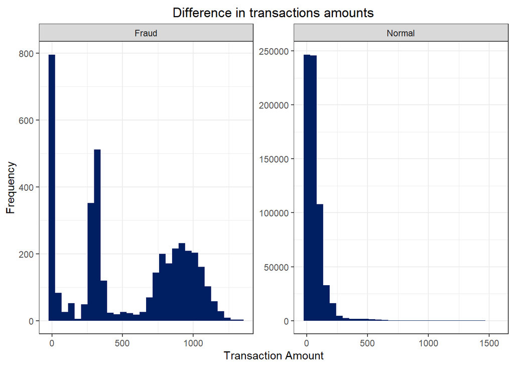

```r
#The data is prompt to have outliers and we will filter them.
#Calculate the limits
lower_limit <- quantile(card_fraud$amt, 0.25) - 20 * IQR(card_fraud$amt)
upper_limit <- quantile(card_fraud$amt, 0.75) + 20 * IQR(card_fraud$amt)

#Clear the data set and make a histogram of transactions
card_fraud %>%
  #Filter the data
  filter(amt >= lower_limit & amt <= upper_limit) %>%
  mutate(is_fraud=ifelse(is_fraud==1, 'Fraud', 'Normal')) %>%
  #Make a histogram
  ggplot(aes(x=amt)) +
  geom_histogram(fill='#001e62') +
  #Add labels
  labs(x='Transaction Amount', y='Frequency', title='Difference in transactions amounts') +
  #Repeat it by the fraud categorical variable
  facet_wrap(~is_fraud, scale='free') +
  #Add aesthetics
  theme_bw() +
  theme(plot.title = element_text(hjust=0.5, vjust=0.5) )
```

```r
#Calculate summary statistics
card_fraud %>%
  #Filter the data to avoid outliers
   filter(amt >= lower_limit & amt <= upper_limit) %>%
  #Rewrite the is_fraud variable
  mutate(is_fraud=ifelse(is_fraud==1, 'Fraud', 'Normal')) %>%
  #Summarise statistics
  group_by(is_fraud) %>%
  summarise(median=median(amt), mean=mean(amt), q25=quantile(amt, 0.25),q75=quantile(amt, 0.75))
```

```
## # A tibble: 2 × 5
##   is_fraud median  mean    q25   q75
##   <chr>     <dbl> <dbl>  <dbl> <dbl>
## 1 Fraud     369.  527.  240.   901.
## 2 Normal     47.1  64.7   9.59  82.3
```

- What types of purchases are most likely to be instances of fraud? Consider category of merchants and produce a bar chart that shows % of total fraudulent transactions sorted in order.

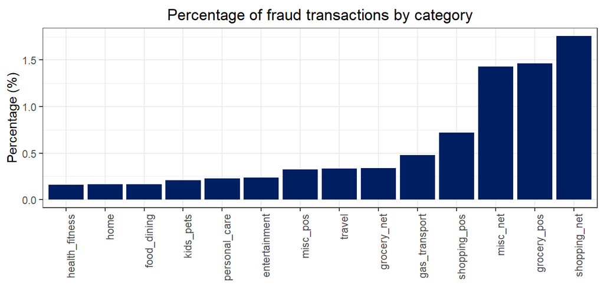

```r
#Make a graph of fraudulent transactions by type of purchases
card_fraud %>%
  #Estimate the fraudulent transactions by type of purchases
  group_by(category,is_fraud) %>%
  summarise(frauds=n()) %>%
  group_by(category) %>%
  mutate(perc=frauds/sum(frauds)) %>%
  filter(is_fraud==1) %>%
  #Make a column graph
  ggplot(aes(x=fct_reorder(category,perc), y=perc*100)) +
    geom_col(fill='#001e62') +
  #Add label and aesthetics
  theme_bw() +
   theme(plot.title = element_text(hjust=0.5, vjust=0.5), axis.text.x = element_text(angle = 90, hjust = 1)) +
  labs(x='', y='Percentage (%)', title='Percentage of fraud transactions by category')
```

- When is fraud more prevalent? Which days, months, hours? To create new variables to help you in your analysis, we use the `lubridate` package and the following code

```r
#Make a new data set
card_fraud2<-card_fraud %>%
mutate(
  date_only = lubridate::date(trans_date_trans_time),
  month_name = lubridate::month(trans_date_trans_time, label=TRUE),
  hour = lubridate::hour(trans_date_trans_time),
  weekday = lubridate::wday(trans_date_trans_time, label = TRUE)
  )

#Day with the most frauds
card_fraud2 %>%
  group_by(weekday) %>%
  summarise(count=n(), perc=count/nrow(.)) %>%
  arrange(desc(count))
```

```
## # A tibble: 7 × 3
##   weekday   count  perc
##   <ord>     <int> <dbl>
## 1 "lun\\." 131419 0.196
## 2 "dom\\." 129550 0.193
## 3 "sáb\\." 104039 0.155
## 4 "mar\\."  82930 0.124
## 5 "vie\\."  78951 0.118
## 6 "jue\\."  76200 0.114
## 7 "mié\\."  67939 0.101
```

```r
#Months with the most frauds
card_fraud2 %>%
  group_by(month_name) %>%
  summarise(count=n(), perc=count/nrow(.)) %>%
  arrange(desc(count))
```

```
## # A tibble: 12 × 3
##    month_name count   perc
##    <ord>      <int>  <dbl>
##  1 May        75801 0.113
##  2 Mar        74478 0.111
##  3 Jun        74214 0.111
##  4 Dic        72986 0.109
##  5 Abr        69876 0.104
##  6 Ene        53806 0.0802
##  7 Feb        50660 0.0755
##  8 Ago        45280 0.0675
##  9 Jul        44974 0.0670
## 10 Set        36533 0.0544
## 11 Nov        36333 0.0541
## 12 Oct        36087 0.0538
```

```r
#Hours with the most frauds
card_fraud2 %>%
  group_by(hour) %>%
  summarise(count=n(), perc=count/nrow(.)) %>%
  arrange(desc(count))
```

```
## # A tibble: 24 × 3
##     hour count   perc
##    <int> <int>  <dbl>
##  1    22 34674 0.0517
##  2    23 34625 0.0516
##  3    18 34131 0.0509
##  4    19 33987 0.0506
##  5    20 33978 0.0506
##  6    13 33972 0.0506
##  7    16 33960 0.0506
##  8    15 33907 0.0505
##  9    17 33842 0.0504
## 10    21 33814 0.0504
## # ℹ 14 more rows
```

- Are older customers significantly more likely to be victims of credit card fraud? To calculate a customer’s age, we use the `lubridate` package and the following code

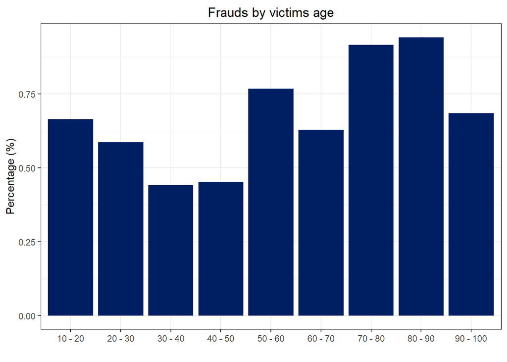

```r
#Transform the dataset to estiamte the ages of all vicitms
card_fraud3<-card_fraud %>%
  mutate(
   age = interval(dob, trans_date_trans_time) / years(1),
    )

# Define the breaks for the age groups
breaks <- seq(10, 100, by = 10)

# Create the categorical variable representing age groups
card_fraud3 %>%
  mutate(age_group = cut(age, breaks = breaks, labels = paste(breaks[-length(breaks)], "-", breaks[-1]), include.lowest = TRUE)) %>%
  #Estimate the total percent of frauds per age group
  group_by(age_group) %>%
  summarise(perc=mean(is_fraud)) %>%
  #Make a column graph
  ggplot(aes(x=age_group, y=perc*100)) +
  geom_col(fill='#001e62') +
  #Add labels and aesthetics
  labs(x='', y='Percentage (%)', title='Frauds by victims age') +
  theme_bw() +
   theme(plot.title = element_text(hjust=0.5, vjust=0.5))
```

The age group from 70 - 90 seems to be the more prompt to fall in frauds. However, the age group from 10-20 also presents a high percentage of likelihood.

- Is fraud related to distance? The distance between a card holder’s home and the location of the transaction can be a feature that is related to fraud. To calculate distance, we need the latidue/longitude of card holders’s home and the latitude/longitude of the transaction, and we will use the [Haversine formula](https://en.wikipedia.org/wiki/Haversine_formula) to calculate distance. I adapted code to [calculate distance between two points on earth](https://www.geeksforgeeks.org/program-distance-two-points-earth/amp/) which you can find below

```r
# distance between card holder's home and transaction
# code adapted from https://www.geeksforgeeks.org/program-distance-two-points-earth/amp/


card_fraud <- card_fraud %>%
  mutate(

    # convert latitude/longitude to radians
    lat1_radians = lat / 57.29577951,
    lat2_radians = merch_lat / 57.29577951,
    long1_radians = long / 57.29577951,
    long2_radians = merch_long / 57.29577951,

    # calculate distance in miles
    distance_miles = 3963.0 * acos((sin(lat1_radians) * sin(lat2_radians)) + cos(lat1_radians) * cos(lat2_radians) * cos(long2_radians - long1_radians)),

    # calculate distance in km
    distance_km = 6377.830272 * acos((sin(lat1_radians) * sin(lat2_radians)) + cos(lat1_radians) * cos(lat2_radians) * cos(long2_radians - long1_radians))

  )
```

Plot a boxplot or a violin plot that looks at the relationship of distance and `is_fraud`. Does distance seem to be a useful feature in explaining fraud?

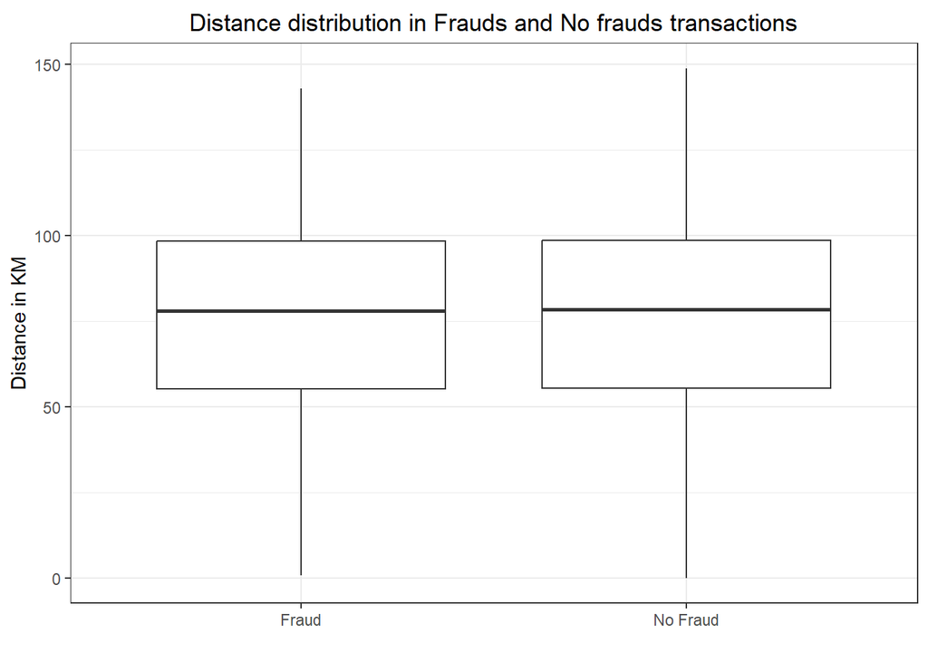

```r
#Make a boxplot graph of distance by fraudulent transactions
card_fraud %>%
  #Rewrite the fraud variable
  mutate(is_fraud=ifelse(is_fraud==1, 'Fraud', 'No Fraud')) %>%
  #Make the boxplot graph
  ggplot(aes(x=is_fraud, y=distance_km)) +
  geom_boxplot() +
  #Add the aesthetics and labels
  theme_bw() +
  labs(x='', y='Distance in KM', title='Distance distribution in Frauds and No frauds transactions') +
   theme(plot.title = element_text(hjust=0.5, vjust=0.5) )
```

Distance doesn’t have a significant impact on fraudulent transaction given that both box plots look highly similar.

# 3 Exploring sources of electricity production, CO2 emissions, and GDP per capita.

```r
# Download electricity data
url <- "https://nyc3.digitaloceanspaces.com/owid-public/data/energy/owid-energy-data.csv"

energy <- read_csv(url) %>%
  filter(year >= 1990) %>%
  drop_na(iso_code) %>%
  select(1:3,
         biofuel = biofuel_electricity,
         coal = coal_electricity,
         gas = gas_electricity,
         hydro = hydro_electricity,
         nuclear = nuclear_electricity,
         oil = oil_electricity,
         other_renewable = other_renewable_exc_biofuel_electricity,
         solar = solar_electricity,
         wind = wind_electricity,
         electricity_demand,
         electricity_generation,
         net_elec_imports,  # Net electricity imports, measured in terawatt-hours
         energy_per_capita, # Primary energy consumption per capita, measured in kilowatt-hours Calculated by Our World in Data based on BP Statistical Review of World Energy and EIA International Energy Data
         energy_per_gdp,    # Energy consumption per unit of GDP. This is measured in kilowatt-hours per 2011 international-$.
         per_capita_electricity, #  Electricity generation per capita, measured in kilowatt-hours
  )

# Download data for C02 emissions per capita https://data.worldbank.org/indicator/EN.ATM.CO2E.PC
co2_percap <- wb_data(country = "countries_only",
                      indicator = "EN.ATM.CO2E.PC",
                      start_date = 1990,
                      end_date = 2022,
                      return_wide=FALSE) %>%
  filter(!is.na(value)) %>%
  #drop unwanted variables
  select(-c(unit, obs_status, footnote, last_updated)) %>%
  rename(year = date,
         co2percap = value, iso_code=iso3c)


# Download data for GDP per capita  https://data.worldbank.org/indicator/NY.GDP.PCAP.PP.KD
gdp_percap <- wb_data(country = "countries_only",
                      indicator = "NY.GDP.PCAP.PP.KD",
                      start_date = 1990,
                      end_date = 2022,
                      return_wide=FALSE) %>%
  filter(!is.na(value)) %>%
  #drop unwanted variables
  select(-c(unit, obs_status, footnote, last_updated)) %>%
  rename(year = date,
         GDPpercap = value, iso_code=iso3c)
```

Making a function for plotting

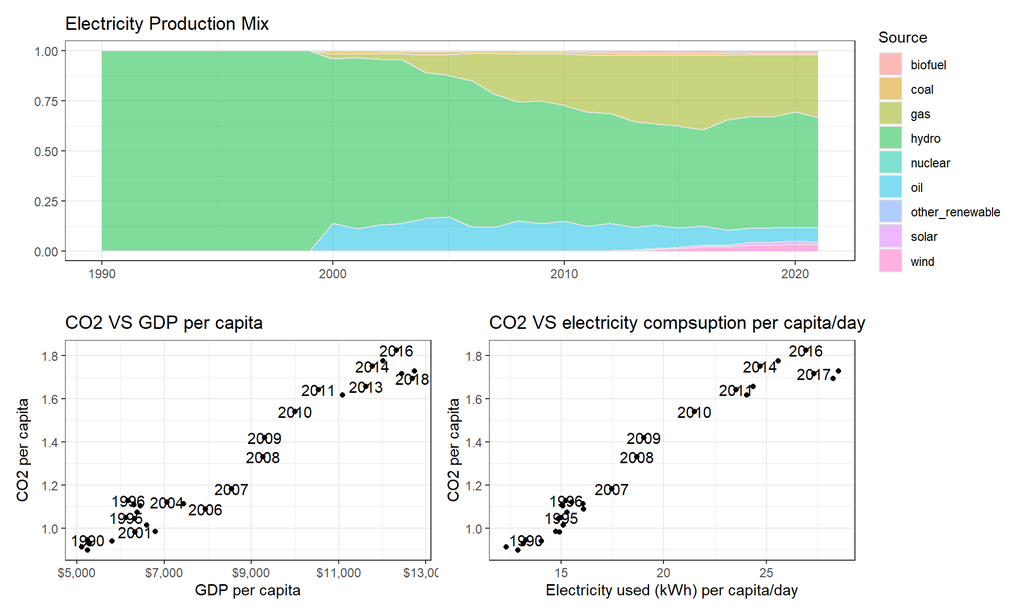

```r
#Merge the data sets
data<-left_join(energy, co2_percap, by=c('iso_code','year'))
data<-left_join(data, gdp_percap, by=c('iso_code','year'))


#Set the plot function
graph_plot<-function(country_code) {

#Save the relevant columns
columns<-colnames(energy)[4:12]
#Make the first graph of stacked area chart of energy distribution
plot1<-data %>%
  #Reshape the energy columns
  pivot_longer(columns, names_to='Source', values_to='Value') %>%
  #Filter by country code
  filter(country==country_code) %>%
  #Clean the data set of NAs
  group_by(year) %>%
  mutate(Value=ifelse(is.na(Value), 0, Value),
    perc=Value/sum(Value, na.rm = TRUE)) %>%
  #Select the appropiate variables
  select(country, year, Value, perc, Source) %>%
  #Make the stacked area graph
  ggplot(aes(x=year, y=perc, fill=Source)) +
  geom_area(colour="grey90", alpha = 0.5, position = "fill") +
  labs(x='', y='', title='Electricity Production Mix') +
  theme_bw()

#Make the second graph of  scatter plot that looks at how CO2 per capita and GDP per capita are related
plot2<-data %>%
  #Filter for the appropiate country
  filter(country==country_code) %>%
  #Make the scatter plot
  ggplot(aes(x=GDPpercap, y=co2percap)) +
  geom_point() +
  #Add text
  geom_text(aes(label = year), check_overlap = TRUE) +
  #Add labels and aesthetics
  labs(x='GDP per capita', y='CO2 per capita', title='CO2 VS GDP per capita') +
  theme_bw() +
  scale_x_continuous(labels = scales::label_dollar())

#Make the third graph of a scatter plot that looks at how electricity usage (kWh) per capita/day GDP per capita are related
plot3<-data %>%
  #Filter by the appropriate country
  filter(country==country_code) %>%
  #Estimate the daily use of energy
  mutate(energy_p_d=energy_per_capita/365) %>%
  #Make the scatter plot
  ggplot(aes(x=energy_p_d, y=co2percap)) +
  geom_point() +
  #Add text
  geom_text(aes(label = year), check_overlap = TRUE) +
  #Add labels and aesthetics
  labs(x='Electricity used (kWh) per capita/day', y='CO2 per capita', title='CO2 VS electricity compsuption per capita/day') +
  theme_bw()

#Combine all the plots into one
combined_plot <- plot1 / (plot2 + plot3)
#Print the result
print(combined_plot)
}

graph_plot('Peru')
```

# 4 Deliverables

There is a lot of explanatory text, comments, etc. You do not need these, so delete them and produce a stand-alone document that you could share with someone. Knit the edited and completed R Markdown (qmd) file as a Word or HTML document (use the “Knit” button at the top of the script editor window) and upload it to Canvas. You must be comitting and pushing your changes to your own Github repo as you go along.

# 5 Details